# Biostatistics Methods 生物统计学方法

# Module 1 Introduction

## Course content

### Statistics & Biostatistics

#### Some Definitions (总体、样本、参数、统计量、变量)

- `Population`: the complete collection of units (individuals or objects) of interest in a study.
- `Parameter (the truth)`: any descriptive measure based on a population (a single-value parameter or a complicated function)
- `Sample`: a smaller subset of the population of interest
- `Statistic (approximation of the truth, prone to error)`: any descriptive measure (of the parameter) based on a sample (synonym: Estimator)

——The true Parameter is invariant to the Sample.

- `Variable`: a characteristic of each element of a population or sample

#### Sampling (抽样)

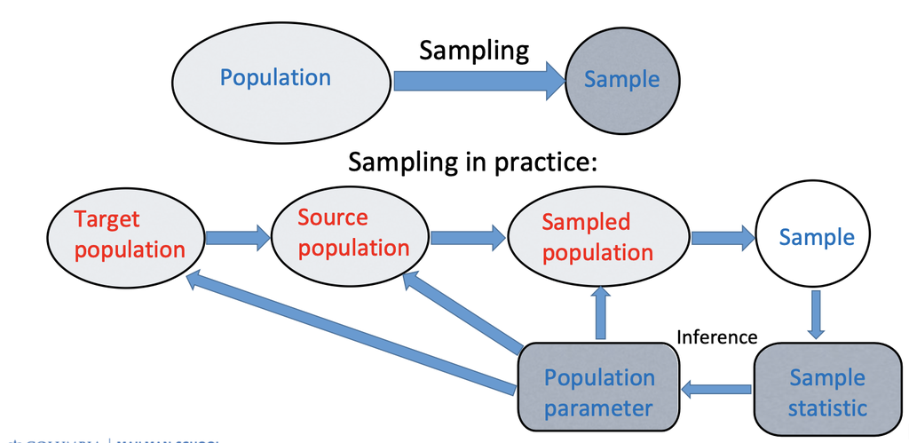

Statistical inference allows generalization from the sample only to the population from which the sample came from (assuming no sampling and response bias!).

If we want to make inference about the target population, we have to make sure that the population from which the sample came from is similar to the target population.

**Sampling Populations**

- The ability to obtain reliable measures of population depends critically on how we sample populations.

Properties of good samples:

- Low sampling error, focus on `precision`
- `Accurate` (or unbiased) estimates

Bias v.s. Variance

- `Bias`: tendency of being inaccurate
- `Variance`: uncertainty due to randomness of samples

#### Types of (structured) Data

- `Qualitative data`: measurements expressed not in terms of numbers but in types or categories.
- `Qualitative variables` can be subdivided into:

`Ordinal variables`: ordered series (e.g., preference, disease severity)

`Nominal variables`: no inherent order or ranking (e.g., blood type)

`Binary variables`: only two options (e.g., pass/fail, yes/no)

- `Quantitative data`: measurements expressed in terms of numbers: e.g., weight, blood pressure, survival time, etc.
- `Quantitative variables` can also be subdivided into:

`Discrete variables`: usually there are gaps between the values e.g., # of pregnancies

`Continuous variable`s: have a set of all possible values within an interval. e.g., body mass index (BMI)

#### Sources of Data

- `Published Source`: government, business, sports statistics are collected and presented in press, online, etc.
- `Experimental Study`: researchers deliberately influence events and investigate the effects of an intervention
- `Survey`: researchers select sample of individuals and record their responses to questions
- `Observational Study`: researchers collect information on the attributesor measurements of interest, without influencing the events

#### Study Design

- Experimental

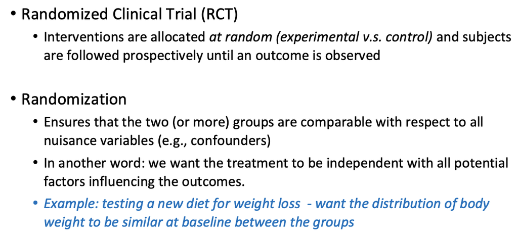

- Observational

Observational studies are to be contrasted with experiments.

• No intervention

• Data collected on an already existing system (practical, less expensive, feasible)

Types of observational studies:

• Case study: descriptive characteristics of a single subject

• Case-control study

[figure not shown]

• Cross-sectional study

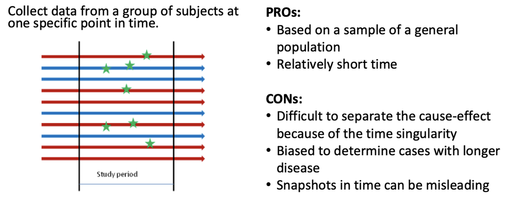

• Cohort studies

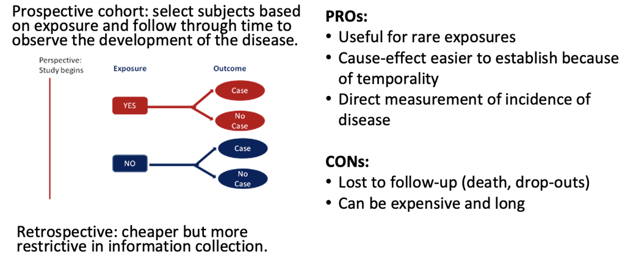

## R code – Data Maniplulation

### Importing Data 读取数据

Here we read csv files `lowbwt_Low.csv` and `lowbwt_Normal.csv`

You will need to change the working directory to your personal file location.

```r
# read and name data 读取并命名数据
low_birth = read.csv("Module 1/lowbwt_Low.csv")
norm_birth = read.csv("Module 1/lowbwt_Normal.csv")
```

### Examine Data Attributes 检查数据属性

```r
# Variable names 列变量名称
names(low_birth)
```

```
## [1] "id"    "smoke" "age"
```

```r
# Data dimension: rows x columns; here: 59 rows and 3 columns 数据维度：行×列
dim(low_birth)
```

```
## [1] 59  3
```

```r
# Number of rows 行数
nrow(low_birth)
```

```
## [1] 59
```

```r
# Number of columns 列数
ncol(low_birth)
```

```
## [1] 3
```

```r
# Head and Tail observations 开头和结尾的观察量
head(low_birth)
```

```
##   id smoke age
## 1 31     0  20
## 2 76     0  20
## 3 44     1  20
## 4 68     1  17
## 5 23     1  19
## 6 45     1  17
```

```r
tail(low_birth)
```

```
##    id smoke age
## 54 19     0  24
## 55 11     1  34
## 56 56     1  31
## 57 65     1  30
## 58 10     0  29
## 59 22     1  32
```

```r
# Check for number of missing values 检查缺失值数量
sum(is.na(low_birth))
```

```
## [1] 0
```

```r
# Examine the classes of each column 检查每列的变量类型
str(low_birth)
```

```
## 'data.frame':    59 obs. of  3 variables:
##  $ id   : int  31 76 44 68 23 45 51 49 71 83 ...
##  $ smoke: int  0 0 1 1 1 1 1 0 0 0 ...
##  $ age  : int  20 20 20 17 19 17 20 18 17 17 ...
```

```r
# Tabulate variable smoke ???
table(low_birth$smoke)
```

```
##
##  0  1
## 29 30
```

### Data Manipulation using `dplyr` 用“dply”进行数据模拟

Note: to apply these changes to the existing data, you must reassign the change.

i.e. `low_birth = filter(low_birth, age < 20)`

NOTE: you will need to install the `{tidyverse}` package. Run `install.packages("tidyverse")` in the Console.

```r
library(tidyverse)
```

```r
# Select only column/variable age 只选择一列变量
dplyr::select(low_birth, age)
```

```
##    age
## 1   20
## 2   20
## 3   20
## 4   17
## 5   19
## 6   17
## 7   20
## 8   18
## 9   17
## 10  17
## 11  18
## 12  20
## 13  19
## 14  20
```

[output cut: 45 more lines]

```r
# Keep only rows where 'age' is less than 20 只保留年龄＜20的行
filter(low_birth, age < 20)
```

```
##    id smoke age
## 1  68     1  17
## 2  23     1  19
## 3  45     1  17
## 4  49     0  18
## 5  71     0  17
## 6  83     0  17
## 7  50     1  18
## 8  33     0  19
## 9  78     1  14
## 10 37     1  17
## 11 34     1  19
## 12 57     0  15
## 13 62     0  15
## 14 25     0  16
## 15 81     0  14
```

```r
# Select rows that contain missing data 选择包括缺失值的行
filter(low_birth, is.na(age))
```

```
## [1] id    smoke age
## <0 rows> (or 0-length row.names)
```

```r
# Remove column age 去掉“年龄”这一列
dplyr::select(low_birth, -age)
```

```
##    id smoke
## 1  31     0
## 2  76     0
## 3  44     1
## 4  68     1
## 5  23     1
## 6  45     1
## 7  51     1
## 8  49     0
## 9  71     0
## 10 83     0
## 11 50     1
## 12 27     1
## 13 33     0
## 14 47     0
```

[output cut: 45 more lines]

```r
# Filter rows: select all 25+ yrs old, smokers 选择所有年龄＞25，抽烟的行
filter(low_birth, age > 25 & smoke == "1")
```

```
##   id smoke age
## 1 77     1  26
## 2 35     1  26
## 3  4     1  28
## 4 79     1  28
## 5 11     1  34
## 6 56     1  31
## 7 65     1  30
## 8 22     1  32
```

```r
# Ordering data by variable/column 'id' 按照“id”对数据排列
arrange(low_birth, id)
```

```
##    id smoke age
## 1   4     1  28
## 2  10     0  29
## 3  11     1  34
## 4  13     0  25
## 5  15     0  25
## 6  16     0  27
## 7  17     0  23
## 8  18     0  24
## 9  19     0  24
## 10 20     1  21
## 11 22     1  32
## 12 23     1  19
## 13 24     0  25
## 14 25     0  16
```

[output cut: 45 more lines]

```r
# Arrange by id in descending order 按id降序对数据排列
arrange(low_birth, desc(id))
```

```
##    id smoke age
## 1  84     1  21
## 2  83     0  17
## 3  82     1  23
## 4  81     0  14
## 5  79     1  28
## 6  78     1  14
## 7  77     1  26
## 8  76     0  20
## 9  75     0  26
## 10 71     0  17
## 11 69     1  23
## 12 68     1  17
## 13 67     1  22
## 14 65     1  30
```

[output cut: 45 more lines]

```r
# Order by multiple columns/variables 按照多列变量排序
arrange(low_birth, smoke, desc(age))
```

```
##    id smoke age
## 1  10     0  29
## 2  43     0  27
## 3  16     0  27
## 4  54     0  26
## 5  75     0  26
## 6  13     0  25
## 7  32     0  25
## 8  46     0  25
## 9  15     0  25
## 10 24     0  25
## 11 36     0  24
## 12 18     0  24
## 13 19     0  24
## 14 17     0  23
```

[output cut: 45 more lines]

```r
# Rename variable 'smoke' to 'Smoking_Status' 对“抽烟”重新命名
rename(low_birth, Smoking_Status = smoke)
```

```
##    id Smoking_Status age
## 1  31              0  20
## 2  76              0  20
## 3  44              1  20
## 4  68              1  17
## 5  23              1  19
## 6  45              1  17
## 7  51              1  20
## 8  49              0  18
## 9  71              0  17
## 10 83              0  17
## 11 50              1  18
## 12 27              1  20
## 13 33              0  19
## 14 47              0  20
```

[output cut: 45 more lines]

```r
# Create a variable for log of 'age' 创建新的变量为“年龄”的对数
mutate(low_birth, log_age = log(age))
```

```
##    id smoke age  log_age
## 1  31     0  20 2.995732
## 2  76     0  20 2.995732
## 3  44     1  20 2.995732
## 4  68     1  17 2.833213
## 5  23     1  19 2.944439
## 6  45     1  17 2.833213
## 7  51     1  20 2.995732
## 8  49     0  18 2.890372
## 9  71     0  17 2.833213
## 10 83     0  17 2.833213
## 11 50     1  18 2.890372
## 12 27     1  20 2.995732
## 13 33     0  19 2.944439
## 14 47     0  20 2.995732
```

[output cut: 45 more lines]

```r
# Centering the data by subtracting the mean from variable 'age' 从变量 "年龄 "中减去平均值，使数据居中
mutate(low_birth, center_age = age - mean(age))
```

```
##    id smoke age center_age
## 1  31     0  20 -2.3050847
## 2  76     0  20 -2.3050847
## 3  44     1  20 -2.3050847
## 4  68     1  17 -5.3050847
## 5  23     1  19 -3.3050847
## 6  45     1  17 -5.3050847
## 7  51     1  20 -2.3050847
## 8  49     0  18 -4.3050847
## 9  71     0  17 -5.3050847
## 10 83     0  17 -5.3050847
## 11 50     1  18 -4.3050847
## 12 27     1  20 -2.3050847
## 13 33     0  19 -3.3050847
## 14 47     0  20 -2.3050847
```

[output cut: 45 more lines]

```r
# Use case_when function to create new age categories 使用 case_when 函数创建新的年龄类别
# Cat 1: Age < 25; Cat 2: 25 < Age < 30. Cat 3: Age > 30
mutate(low_birth, new_age = case_when(age < 25 ~ 1,
                                      age >= 25 & age < 30 ~ 2,
                                      age > 30 ~ 3))
```

```
##    id smoke age new_age
## 1  31     0  20       1
## 2  76     0  20       1
## 3  44     1  20       1
## 4  68     1  17       1
## 5  23     1  19       1
## 6  45     1  17       1
## 7  51     1  20       1
## 8  49     0  18       1
## 9  71     0  17       1
## 10 83     0  17       1
## 11 50     1  18       1
## 12 27     1  20       1
## 13 33     0  19       1
## 14 47     0  20       1
```

[output cut: 45 more lines]

### Combine Data Sets 合并数据集

```r
# stack low_birth & norm_birth
low_and_norm = rbind(low_birth, norm_birth)

# combine by specific variable
admin_birth = read.csv("Module 1/lowbwt_Admin.csv")
birth_final = full_join(admin_birth, low_and_norm, by = "id")

# export data
write.csv(birth_final, file = "Module 1/birth_final.csv")
```